# notes2

Grace Falken

4/7/2022

## Useful shit

```r
# comments follow pound symbols ... in rmd bodies this creates headers

#you can save an r object on your computer (you can also save functions this way)
#     save(object,file="new_object.RData")
#     load("new_object.RData")
#these are saved in the working directory
```

`getwd()` `setwd("/Users/gracefalken/Desktop/PPM Year 1/Q3 Spring/CSSS 508")` ^ Markdown files automatically set where they’re saved as the working directory

For journal articles, Breon suggests using rrtools for journal articles and huskydown for UW dissertations.

To run a `.R` script within an `.Rmd` and `.R`, you can use the `source()` function. (E.g., source the cleaning script from an external script).

## Data and Subsetting

```r
library(gapminder)
str(gapminder) # notice that factor variables are a variable where numeric values are tied to categories (like a likert scale) ("categorical data with an underlying numeric representation")
```

```
## tibble [1,704 × 6] (S3: tbl_df/tbl/data.frame)
##  $ country  : Factor w/ 142 levels "Afghanistan",..: 1 1 1 1 1 1 1 1 1 1 ...
##  $ continent: Factor w/ 5 levels "Africa","Americas",..: 3 3 3 3 3 3 3 3 3 3 ...
##  $ year     : int [1:1704] 1952 1957 1962 1967 1972 1977 1982 1987 1992 1997 ...
##  $ lifeExp  : num [1:1704] 28.8 30.3 32 34 36.1 ...
##  $ pop      : int [1:1704] 8425333 9240934 10267083 11537966 13079460 14880372 12881816 13867957 16317921 22227415 ...
##  $ gdpPercap: num [1:1704] 779 821 853 836 740 ...
```

```r
#notice these are panel data
```

We want to use `dplyr` to filter the data into subsets

```r
library(dplyr)

gapminder %>% filter(country=="Algeria") # gives the subsample of all observations for algeria
```

```
## # A tibble: 12 × 6
##    country continent  year lifeExp      pop gdpPercap
##    <fct>   <fct>     <int>   <dbl>    <int>     <dbl>
##  1 Algeria Africa     1952    43.1  9279525     2449.
##  2 Algeria Africa     1957    45.7 10270856     3014.
##  3 Algeria Africa     1962    48.3 11000948     2551.
##  4 Algeria Africa     1967    51.4 12760499     3247.
##  5 Algeria Africa     1972    54.5 14760787     4183.
##  6 Algeria Africa     1977    58.0 17152804     4910.
##  7 Algeria Africa     1982    61.4 20033753     5745.
##  8 Algeria Africa     1987    65.8 23254956     5681.
##  9 Algeria Africa     1992    67.7 26298373     5023.
## 10 Algeria Africa     1997    69.2 29072015     4797.
## 11 Algeria Africa     2002    71.0 31287142     5288.
## 12 Algeria Africa     2007    72.3 33333216     6223.
```

Packages w the same-named functions as in base R temporarily overwrite the base functions To use those functions, call the package where the function is: `stats::filter`

And thus now we arrive at discussing the pipe. These read left-to-right:

For our subsampel command, the statement `country=="Algergia"` returns true and false for this logic statement.

### Logical Operators

`==` tests for equivalency.

`!=` not equal to

`>` and fam

`%in%` checks if equal to one of several values

`&` both conditions need to hold

`|` at least one condition holds (OR)

`!` inverts logical condition

```r
gapminder %>% filter(country=="Oman" & year > 1980)
```

```
## # A tibble: 6 × 6
##   country continent  year lifeExp     pop gdpPercap
##   <fct>   <fct>     <int>   <dbl>   <int>     <dbl>
## 1 Oman    Asia       1982    62.7 1301048    12955.
## 2 Oman    Asia       1987    67.7 1593882    18115.
## 3 Oman    Asia       1992    71.2 1915208    18617.
## 4 Oman    Asia       1997    72.5 2283635    19702.
## 5 Oman    Asia       2002    74.2 2713462    19775.
## 6 Oman    Asia       2007    75.6 3204897    22316.
```

```r
#saving a subset as an object
china <- gapminder %>% filter(country=="China")
```

## Plotting with ggplot2

The core idea here is layered grammar of graphics: we can break up elemenets of a plot into pieces and combine them.

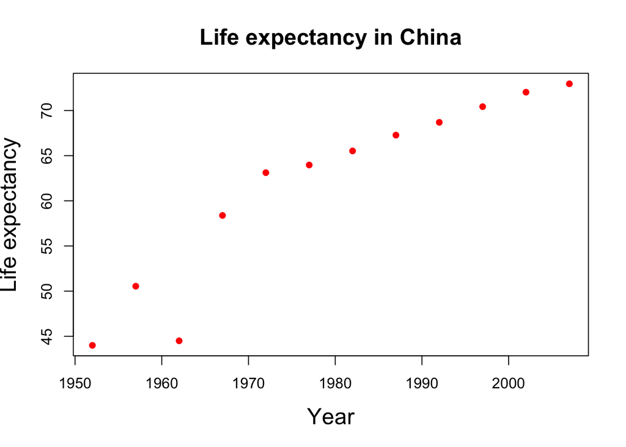

```r
plot(lifeExp ~ year,
     data = china,
     xlab = "Year",
     ylab = "Life expectancy",
     main = "Life expectancy in China",
     col = "red",
     cex.lab = 1.5,
     cex.main= 1.5,
     pch = 16)
```

Versus the `ggplot2` version

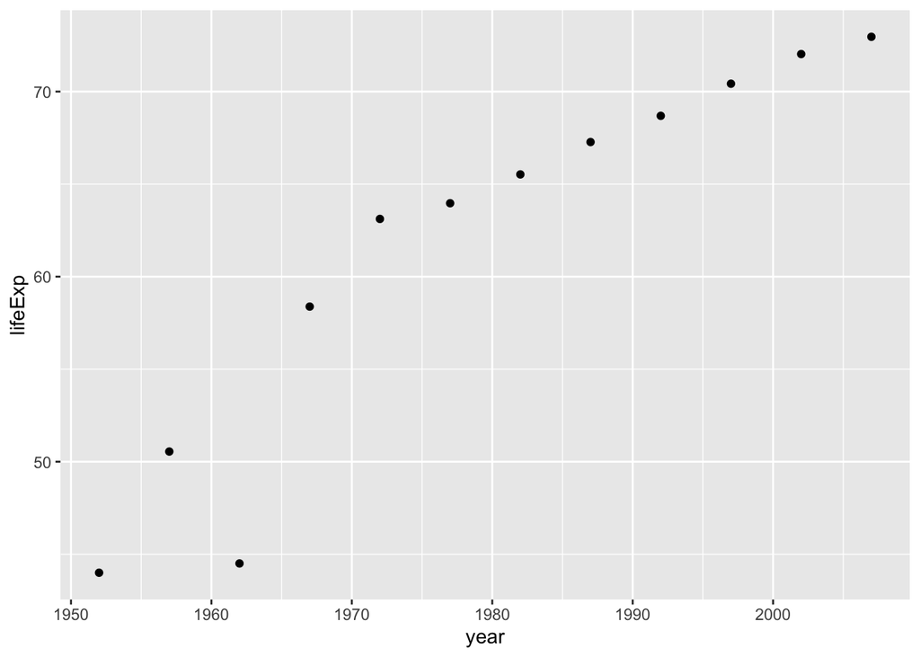

```r
ggplot(data = china,
       aes(x = year, y = lifeExp)) +
    geom_point()
```

Add layers using `+`. Aesthetics determine how the layers appear. Set aesthetics using arguments inside of layer functions. Aesthetics also determine how data map to appearances.

### Layers

`ggplot()` initializes & specifies input data `geom_point()` scatterplot `geom_line()` lines `ggtitle`, `xlab()`, `ylab()`: layers of labels `facet_wrap()`: layer creating separate panels stratified by some factor wrapping around `facet_grid()`: same idea, but can split by two variables along rows and columns (e.g. `facet_grid(gender ~ age_group)`) `theme_bw()`: replace default gray background with black-and-white

### Aesthetics

`x`, `y`: coordinate values to use `color`: set color of elements based on some data value `group`: describe which points are conceptually grouped together for the plot (often used with lines) `size`: set size of points/lines based on some data value `alpha`: set transparency based on some data value

Arguments inside the `aes()` (mapping aesthetics) depend on the data you’re using. Arguments inside the layers (setting aesthetics) do not.

### Plots babieeeeee

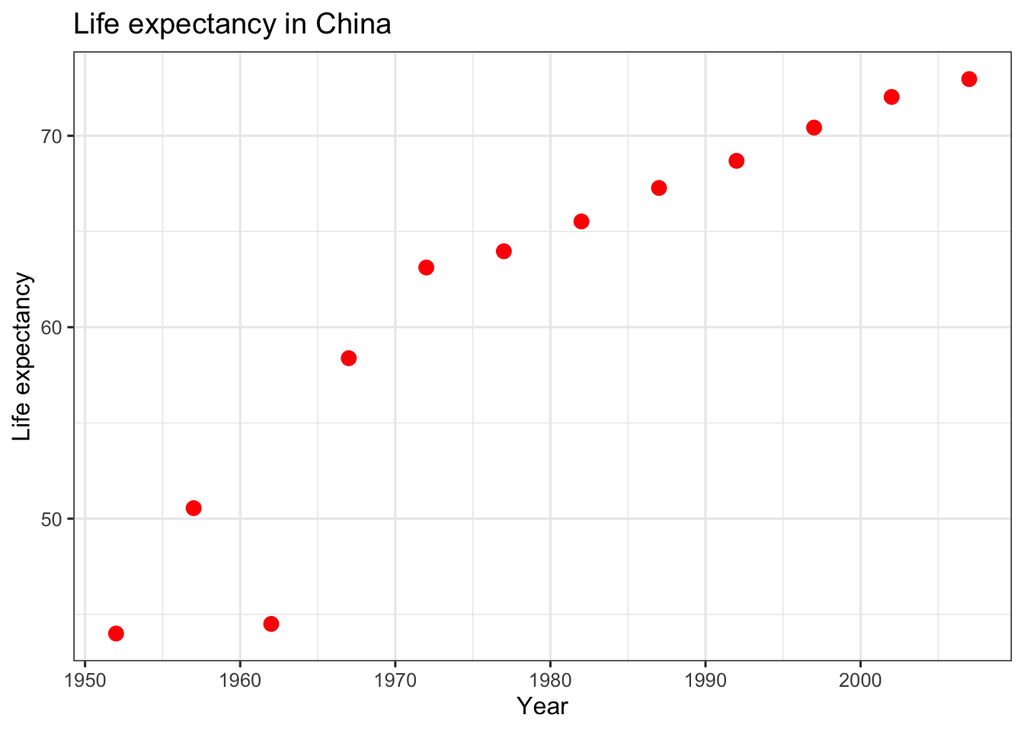

```r
ggplot(data = china,
       aes(x = year, y = lifeExp)) +
  geom_point(color="red", size=3) +
  xlab("Year") +
  ylab("Life expectancy") +
  ggtitle("Life expectancy in China") +
  theme_bw(base_size=12) # changes the background color and makes the base text size bigger
```

Let’s say we want to instead plot all the countries

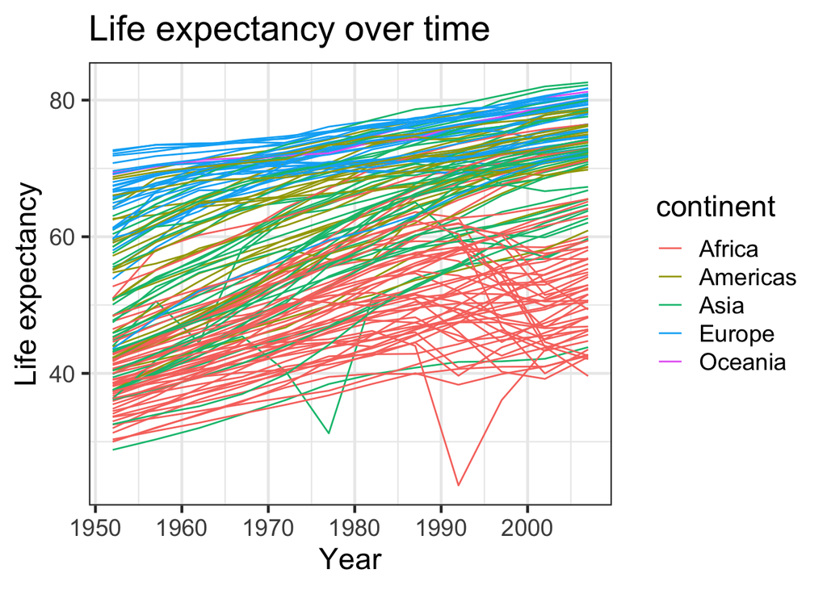

```r
# switch to lines and need to group by country. drop size=3
# also as an aesthetic add color=continent
ggplot(data = gapminder,
       aes(x = year, y = lifeExp,
           group = country,
           color=continent)) +
  geom_line() +
  xlab("Year") +
  ylab("Life expectancy") +
  ggtitle("Life expectancy over time") +
  theme_bw(base_size=18)
```

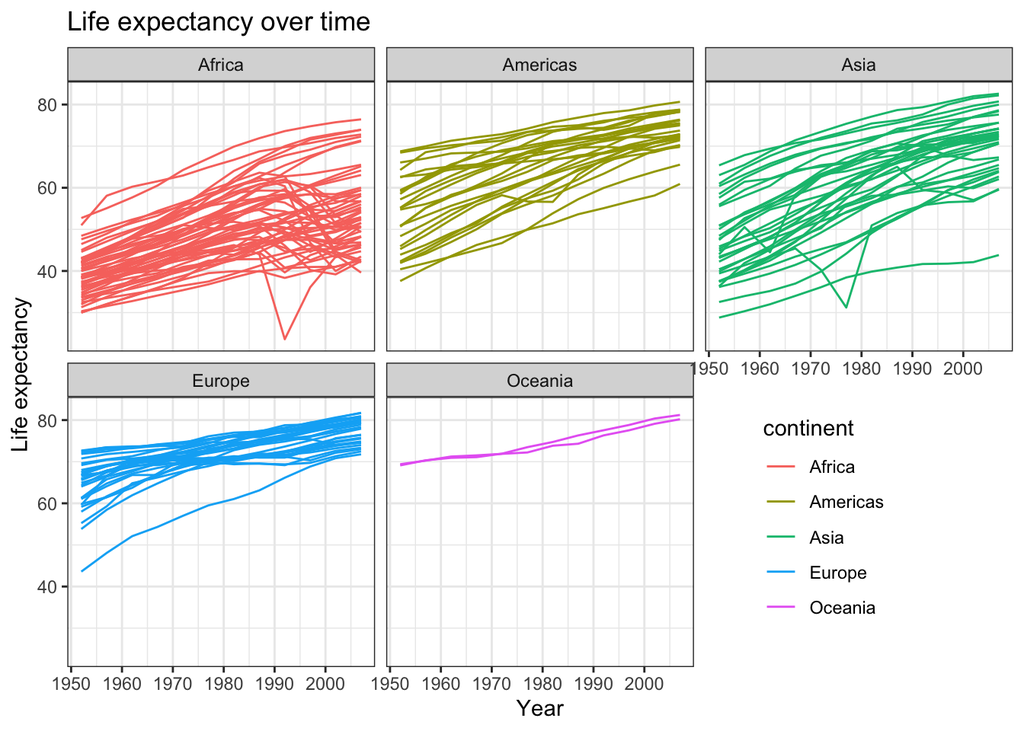

```r
#split these out:
# drop base_size18 to make the x axis labels legible
# legend.position = assigned coords to move it elsewhere ... or instead to drop the legend
#     write "theme(legend.position = "none")"
ggplot(data = gapminder,
       aes(x = year, y = lifeExp,
           group = country,
           color=continent)) +
  geom_line() +
  xlab("Year") +
  ylab("Life expectancy") +
  ggtitle("Life expectancy over time") +
  theme_bw() +
  facet_wrap(~ continent) +
  theme(legend.position = c(0.8, 0.25))
```

To store a plot, assign it to a name. This will not display the graph. You can then use this object to add more layers.

Syntactal note: you can enter a line break after `<-` assignment operators, `,` commas (for example between options).

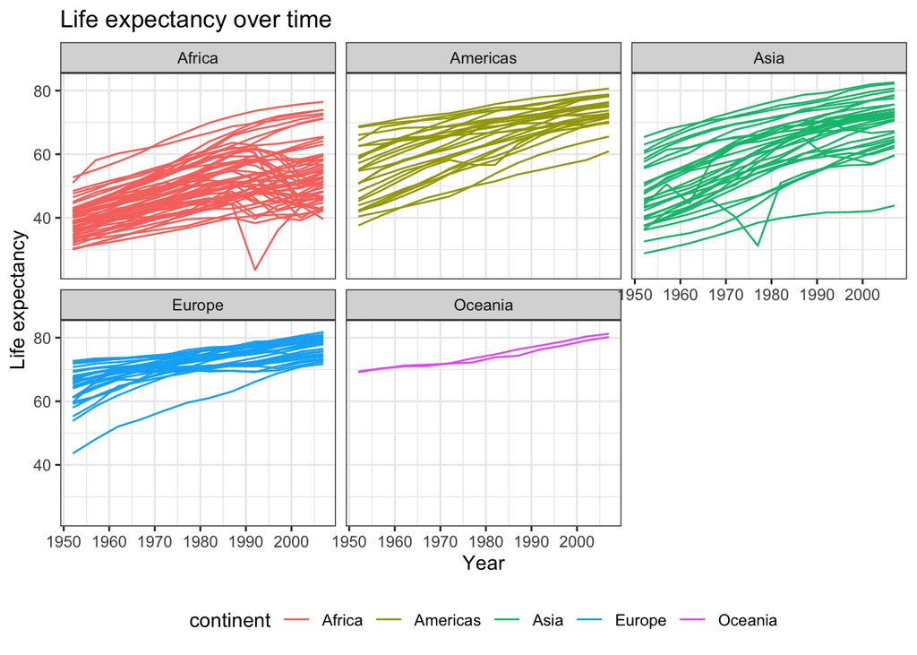

```r
lifeExp_by_year <-
  ggplot(data = gapminder,
       aes(x = year, y = lifeExp,
           group = country,
           color=continent)) +
  geom_line() +
  xlab("Year") +
  ylab("Life expectancy") +
  ggtitle("Life expectancy over time") +
  theme_bw() +
  facet_wrap(~ continent) +
  theme(legend.position = "none")

lifeExp_by_year + theme(legend.position ="bottom")
```

When adding additional layers, you can change the axis ranges, make them log or sqrt scale.

Text and ticks can be edited most easily in the `theme()` layer of a graph. Note this is different from `theme_bw()` and should always *follow* those more specific themes governing backgrounds.

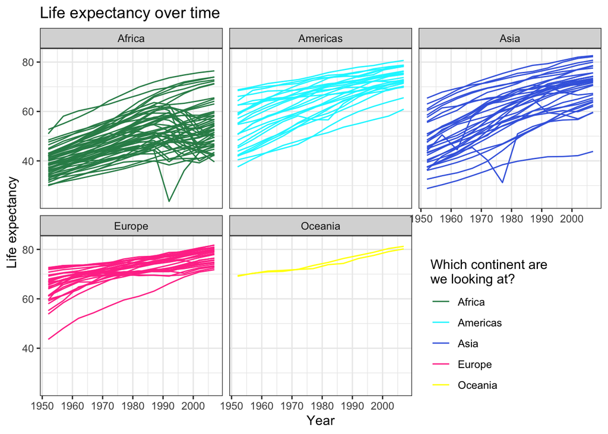

```r
lifeExp_by_year +
  theme(legend.position = c(0.8, 0.2)) +
  scale_color_manual(
    name = "Which continent are\nwe looking at?", # \n adds a line break
    values = c("Africa" = "seagreen", "Americas" = "turquoise1",
               "Asia" = "royalblue", "Europe" = "violetred1", "Oceania" = "yellow"))
```

*Scales* are layers that control how the mapped aesthetics appear. You can modify these with a `scale_[aesthetic]_[option]()` layer where `[aesthetic]` is `color`, `shape`, `linetype`, `alpha`, `size`, `fill`, etc. and `[option]` is something like `manual`, `continuous` or `discrete` (depending on nature of the variable).

When you knit an R Markdown file, any plots you make are automatically saved in the “figure” folder in `.png` format. If you want to save another copy (perhaps of a different file type for use in a manuscript), use `ggsave()`:

`ggsave("I_saved_a_file.pdf", plot = lifeExp_by_year,` `height = 3, width = 5, units = "in")`